# EDA on the Activity Data

In this project we will analyze some properties of the data at hand to answer the questions posed. This assignment lies within the scope of the course on Reproducible research at Coursera. For further information refer to [this link.](https://www.coursera.org/learn/reproducible-research)

First we load the data, have a look at the variables and dimension and correct the class of dates.

```r
library(ggplot2)
library(dplyr)
activity <- read.csv('activity.csv')
head(activity)
```

```
##   steps       date interval
## 1    NA 2012-10-01        0
## 2    NA 2012-10-01        5
## 3    NA 2012-10-01       10
## 4    NA 2012-10-01       15
## 5    NA 2012-10-01       20
## 6    NA 2012-10-01       25
```

```r
dim(activity)
```

```
## [1] 17568     3
```

```r
activity$date <- as.Date(as.character(activity$date))
```

### 1. Number of steps taken per day

Ignoring the missing values as specified in the instructions, we group the data by steps per day and calculate the steps taken per day, stored in steps_by_day, and plot the corresponding histogram.

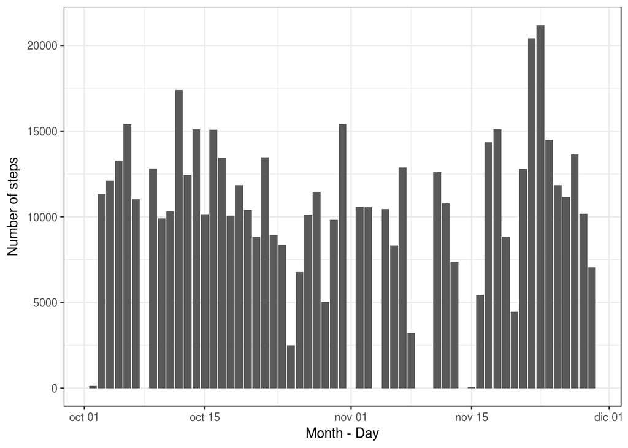

```r
clean_activity <- activity[!is.na(activity$steps),]
steps_by_day <- summarise(group_by(clean_activity, date), steps = sum(steps))
ggplot(steps_by_day, aes(x=date, y=steps)) + geom_histogram(stat="identity") +
  ylab("Number of steps") + xlab("Month - Day") + theme_bw()
```

The mean and median of the time series of steps taken per day are respectively:

```r
print(mean(steps_by_day$steps))
```

```
## [1] 10766.19
```

```r
print(median(steps_by_day$steps))
```

```
## [1] 10765
```

### 2. Average daily activity pattern

Now grouping according to which time interval the steps taken belong to we get the following.

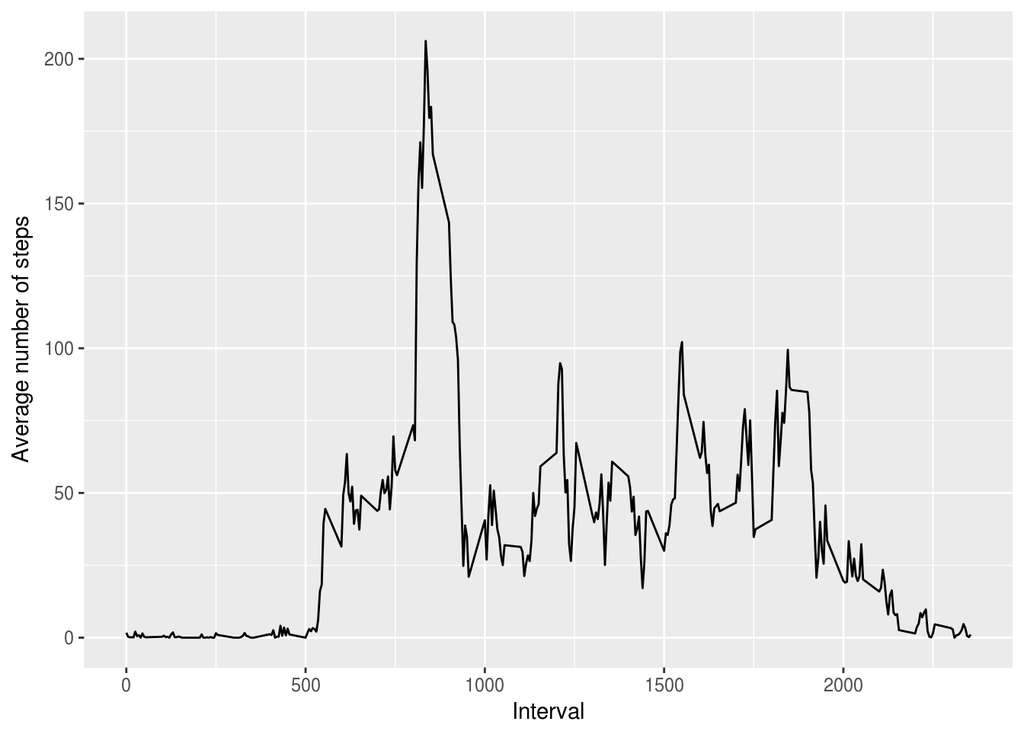

```r
steps_by_interval <- summarise(group_by(activity, interval), steps = mean(steps, na.rm = TRUE))
ggplot(steps_by_interval, aes(x = interval, y = steps)) + geom_line() + xlab('Interval') +
  ylab('Average number of steps')
```

And the interval which on average contains the maximum number of steps is:

```r
steps_by_interval$interval[which.max(steps_by_interval$steps)]
```

```
## [1] 835
```

### 3. Imputing missing values

As we have seen NA’s may cause problems and up until now they have been omitted. Since there are no missing values for date or interval, the total number of missing rows coincides with the total number of NA’s in the steps column, which is:

```r
sum(is.na(activity$steps))
```

```
## [1] 2304
```

```r
new_activity <- activity
for (i in 1:length(new_activity$steps)){
  if(is.na(new_activity$steps[i])) new_activity$steps[i] <- steps_by_day$steps[which.max(steps_by_day$date == activity$date[i])]
}
sum(is.na(new_activity$steps))
```

```
## [1] 0
```

As desired. Now conducting the same analysis as in (1) over the newly created dataset we devise that:

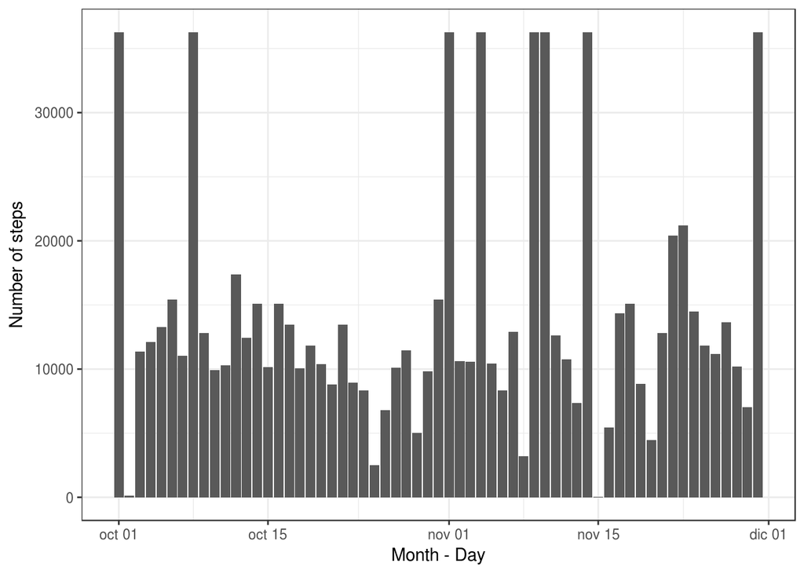

```r
steps_by_day <- summarise(group_by(new_activity, date), steps = sum(steps))
ggplot(steps_by_day, aes(x=date, y=steps)) + geom_histogram(stat="identity") +
  ylab("Number of steps") + xlab("Month - Day") + theme_bw()
```

```r
print(mean(steps_by_day$steps))
```

```
## [1] 14113.31
```

```r
print(median(steps_by_day$steps))
```

```
## [1] 11458
```

Yielding a diferent landscape, probably noisier, than that depicted in (1).

### 4. Are there differences in activity patterns between weekdays and weekends

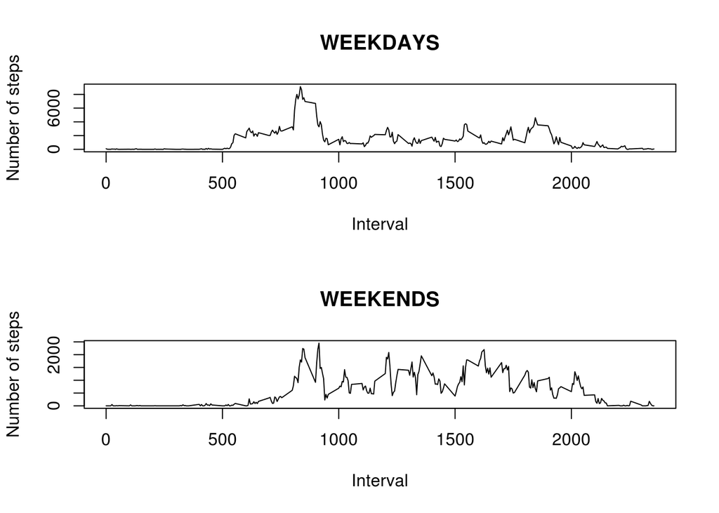

```r
list <- c('lun','mar','mié','jue','vie')
clean_activity$factor <- lapply(clean_activity$date, function(x) weekdays(x, abbreviate= TRUE) %in% list )
weekdays = summarise(group_by(clean_activity[clean_activity$factor == TRUE,], interval = interval), steps = sum(steps))
weekends = summarise(group_by(clean_activity[clean_activity$factor == FALSE,], interval = interval), steps = sum(steps))
par(mfrow = c(2,1))
plot(weekdays$interval, weekdays$steps, type = 'l', xlab = 'Interval', ylab = 'Number of steps', main = 'WEEKDAYS')
plot(weekends$interval, weekends$steps, type = 'l', xlab = 'Interval', ylab = 'Number of steps', main = 'WEEKENDS')
```